# Analysis of NYC Bike Share Citi Bike Data

## by Minjian Wu

## Investigation Overview

we are motivated by a few questions, for example: Where do Citi Bikers ride? How far do they go? When are most trips taken in terms of time of day, day of the week, or month of the year? Which stations are most popular? How long does the average trip take? Does any of these depend on if a user is a subscriber or customer, a male or female, and/or some certain age? We are going to find these out from exploration of the NYC bike share data collected for the year of 2020. We will leverage Python's visualisation libraries to help with our analyses.

## Dataset Overview

The data includes (for each month of a year):

- Trip Duration in seconds
- Start Time and Date
- Stop Time and Date
- Start Station Name
- End Station Name
- Station ID
- Station Lat/Long
- Bike ID
- User Type (Customer = 24-hour pass or 3-day pass user; Subscriber = Annual Member)
- Gender (0 = unknown; 1 = male; 2 = female)
- Year of Birth

This data has been processed to remove trips that are taken by staff as they service and inspect the system, trips that are taken to/from any of the “test” stations, and any trips that were below 60 seconds in length (potentially false starts or users trying to re-dock a bike to ensure it's secure).

## Locations for most popular start stations

Pin point the top 10 most popular bike ride start stations on a map

Make this Notebook Trusted to load map: File -> Trust Notebook

[interactive chart not shown]

## Locations for most popular end stations

Pin point the top 10 most popular bike ride end stations on a map

Make this Notebook Trusted to load map: File -> Trust Notebook

[interactive chart not shown]

So, the top start and end stations share exactly the same locations except for slightly different ranking for the top 10 destination bike stations! Since we have got rid of those trips that start and end at the same location (i.e. those with a straight line distance of zero), the coincidence that most trips still start and end between the same 10 stations indicates a true popularity for bikes at these locations - near parks and/or central. So if a company was to invest in putting more bikes or in setting up a snacks/drinks bar/mobile shop then these locations are ideal.

## Most popular month in 2020 for bike rides

What is the most common time that a bike ride takes place - which month in year 2020?

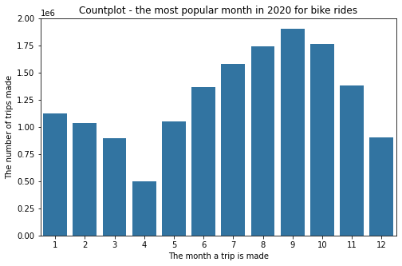

The ride time peaks during the summer months as expected, with September being the busiest month.

## Most popular day in a month for bike rides

What is the most common time that a bike ride takes place - which day in a month?

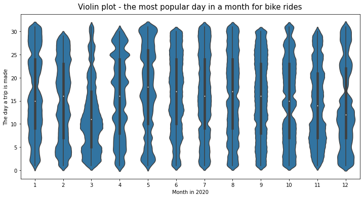

There doesn't appear to be a particular pattern around the activities each day in a month. Otherwise, one observation we can make is that the number of daily bike rides almost flats out at high levels throughout August and September. One could say that throughout 2020, the first half of each month has more bike riding activities than the second half, but the difference would only be marginal.

## Most popular time in a day for bike rides

What is the most common time that a bike ride takes place - which time in a day?

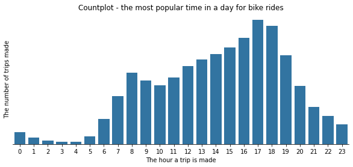

Within a day, bike rides usually peak at 8am and then around 5pm, with more people ride bikes in the afternoon, as bike activities drop slightly in the morning passing the peak time at 8 and pick up the pace gradually from lunchtime all the way towards late afternoon. This pattern seems to follow a typical work/social/home schedule and it is not affected by whether the day is in a warm/hot or cold month. It then follows that the peaks are likely related to people using bikes to commute between work and home.

## Between-station distance vs trip duration by gender/user type

Data show that shorter distance trips do not necessarily take shorter times to complete, and we think that it is because people may make stops on the way or take detours / longer routes. Could this be linked to behaviour in a particular gender or the subscription type (24-hr/3-day pass or annual membership)?

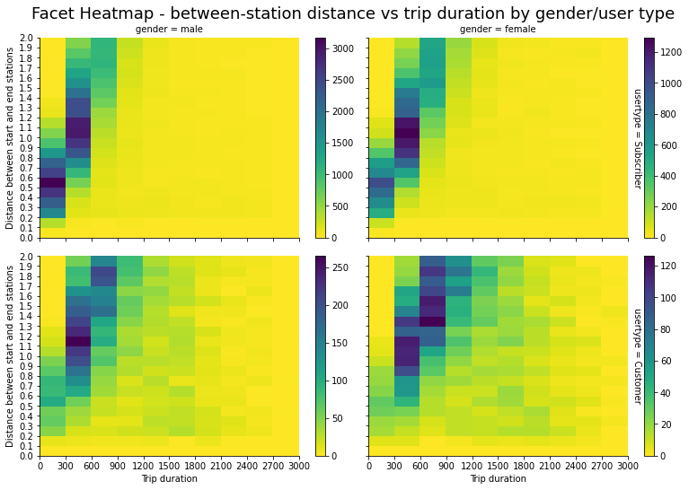

More darker colours are on the right of the plots for customers (bottom row) than for subscribers (top row). This illustrates significantly fewer (in proportion) subscribers spend longer times on bike rides than customers. In other words, customer users (who are on a 24-hr or 3-day pass) tend to spend more time on their bike ride. This makes sense because customers would wish to make most use of their limited-time passes.

On the other hand, the darker colours follow a steeper line for male users (left column) than that for female users (right column), but these colours do not comparably (between male and female) occupy more areas to the right of the plots. This means that there is no tendency for women to spend more / less time on a ride than men other than due to speed of ride.

## Between-station distance vs trip duration by age

Data show that shorter distance trips do not necessarily take shorter times to complete, and we think that it is because people may make stops on the way or take detours / longer routes. Could this also be linked to behaviour in a particular age group?

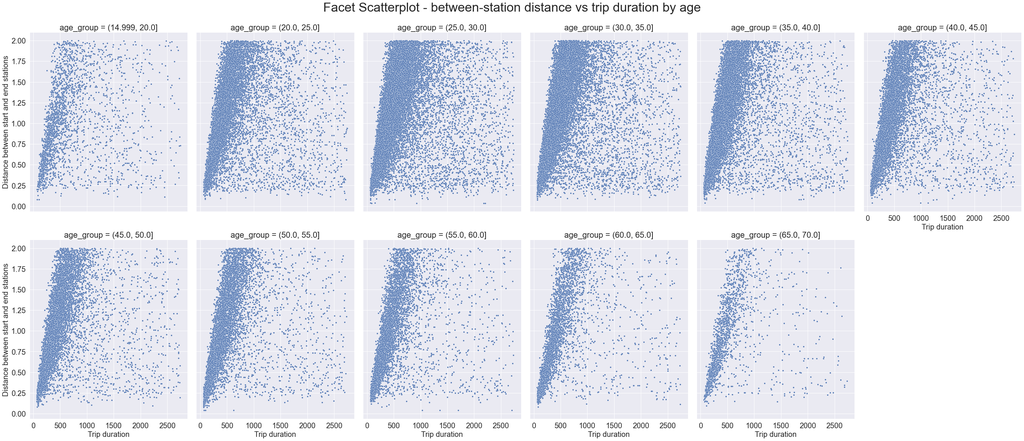

There is no differential pattern associated with age - most people spend time on trips proportional to distance between stations and there is no pattern in the spread of points to the right of each plot.